# STAT 240: Chapter 5: Binomial and Normal Distribution

# Normal Approximation of Binomial Distributions

> If $X \sim Binom(n, p)$, then $X \stackrel{\text{approx}}{\sim}\text{N}(np, \sqrt{np(1-p)})$.
- It is important to remember the **binomial distribution is discrete**, and the **normal distribution is continuous**. However, aside from this key difference, their probability distributions are mathematically linked.
- If $n$ is large enough, and $p$ is not too close to 0 or 1, the binomial distribution can be **approximated** by the normal distribution.
- A rule of thumb for “large enough” is if $np(1-p) \geq 10$.
- Here is an example where the assumption is satisfied.
  - $n = 100$
  - $p = 0.5$
  - $np(1-p) = 25$

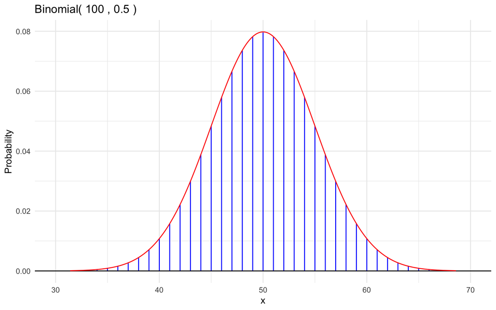

```r
## Assumptions satisfied
n = 100
p = 0.5
mu = n*p
sigma = sqrt(n*p*(1-p))

gbinom(n, p, scale=TRUE) +
  geom_norm_density(mu, sigma, color = "red") +
  theme_minimal()
```

- Here is an example where the assumption is **not satisfied**.
  - $n = 100$
  - $p = 0.01$
  - $np(1-p) = 0.99$

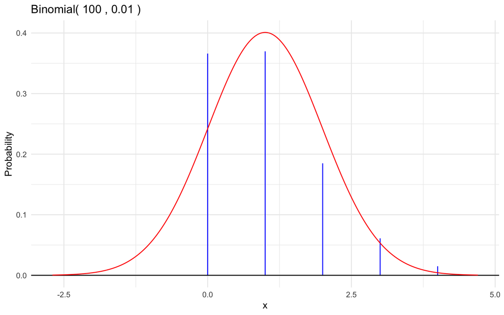

```r
## Criteria not satisfied
n = 100
p = 0.01
mu = n*p
sigma = sqrt(n*p*(1-p))

gbinom(n, p, scale=TRUE) +
  geom_norm_density(mu, sigma, color = "red") +
  theme_minimal()
```